# Лабораторная работа №7

Операционные системы

Гасанова Ш. Ч.

Российский университет дружбы народов, Москва, Россия

30 марта 2025

## Цель

Ознакомление с инструментами поиска файлов и фильтрации текстовых данных. Приобретение практических навыков: по управлению процессами (и заданиями), по проверке использования диска и обслуживанию файловых систем.

## Задание

1. Осуществить вход в систему, используя соответствующее имя пользователя. Записать в файл file.txt названия файлов, содержащихся в каталоге /etc. Дописать в этот же файл названия файлов, содержащихся в домашнем каталоге.
2. Вывести имена всех файлов из file.txt, имеющих расширение .conf, после чего записать их в новый текстовой файл conf.txt.
3. Определить, какие файлы в домашнем каталоге имеют имена, начинающиеся с символа c.
4. Вывести на экран (по странично) имена файлов из каталога /etc, начинающиеся с символа h.
5. Запустить в фоновом режиме процесс, который будет записывать в файл ~/logfile файлы, имена которых начинаются с log. Удалить файл ~/logfile.

## Задание

6. Запустить из консоли в фоновом режиме редактор gedit. Определить идентификатор процесса gedit, используя команду ps, конвейер и фильтр grep.
7. Прочесть справку (man) команды kill, после чего использовать её для завершения процесса gedit.
8. Выполнить команды df и du, предварительно получив информацию об этих командах, с помощью команды man.
9. Воспользовавшись справкой команды find, вывести имена всех директорий, имеющихся в домашнем каталоге.

## Выполнение лабораторной работы

Вхожу в систему, используя соответствующее имя пользователя. Записываю в файл file.txt названия файлов, содержащихся в каталоге /etc

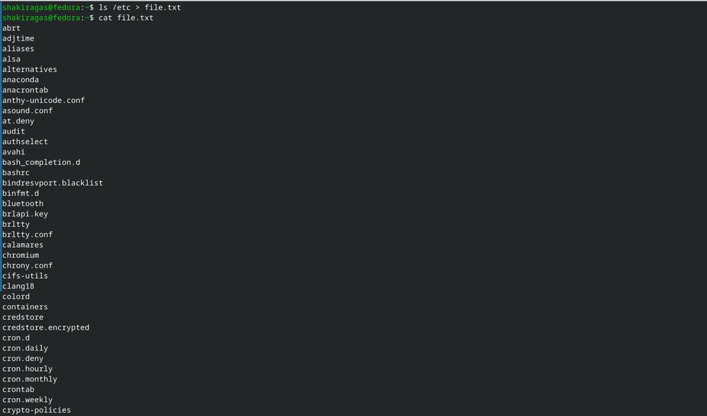

Запись в файл названия файлов

## Выполнение лабораторной работы

Дописываю в этот же файл названия файлов, содержащихся в домашнем каталоге

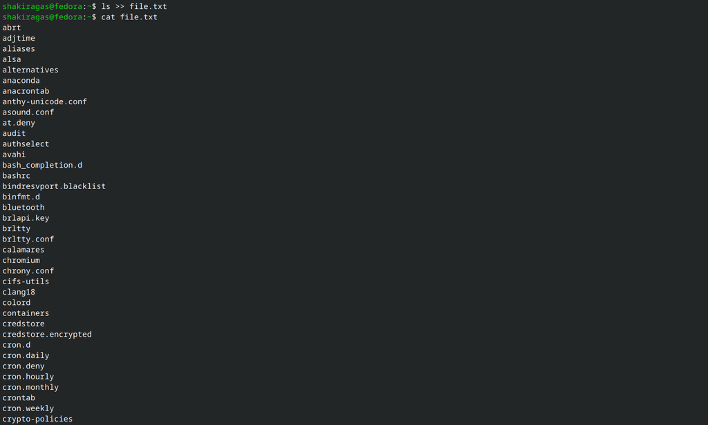

Дописывание названий файлов

## Выполнение лабораторной работы

Вывожу имена всех файлов из file.txt, имеющих расширение .conf

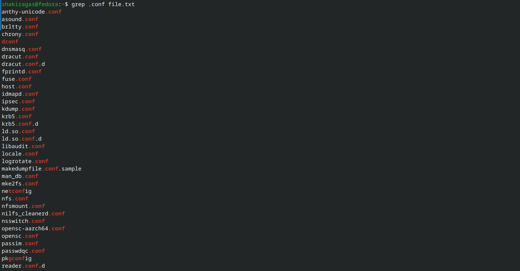

Вывод имен всех файлов из file.txt

## Выполнение лабораторной работы

Записываю их в новый текстовой файл conf.txt

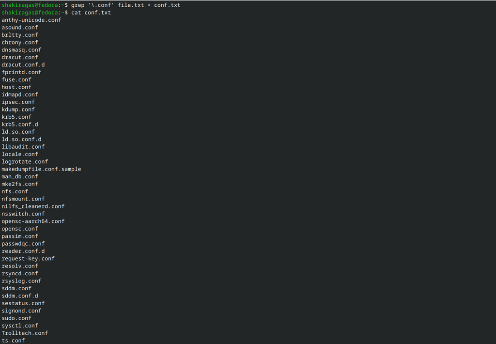

Запись файлов в новый текстовый файл

## Выполнение лабораторной работы

Определяю, какие файлы в домашнем каталоге имеют имена, начинающиеся с символа c

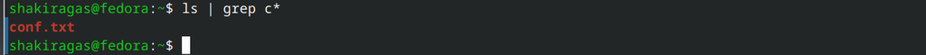

Определение файлов, начинающихся с “с”

## Выполнение лабораторной работы

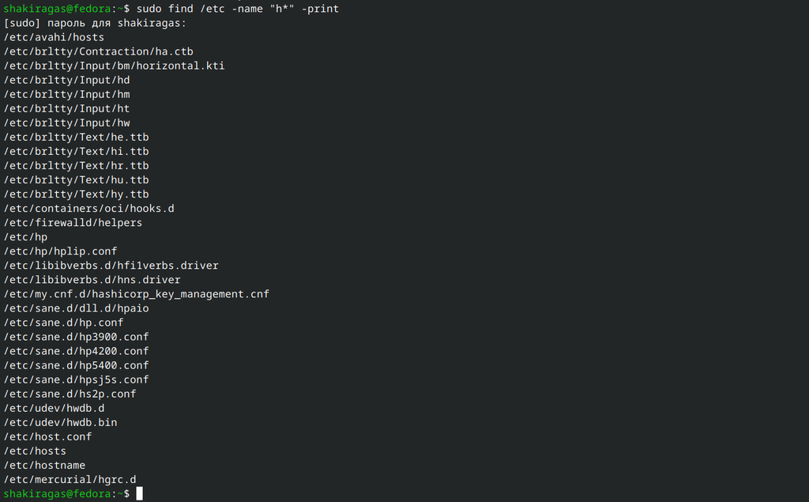

Вывод файлов, начинающихся с “h”

## Выполнение лабораторной работы

Запускаю в фоновом режиме процесс, который будет записывать в файл ~/logfile файлы, имена которых начинаются с log. Удаляю файл ~/logfile

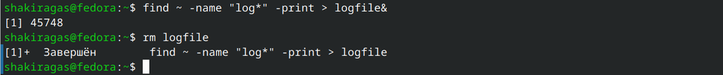

Запуск в фоновом режиме процесса, записывающего файлы, начинающиеся на log

## Выполнение лабораторной работы

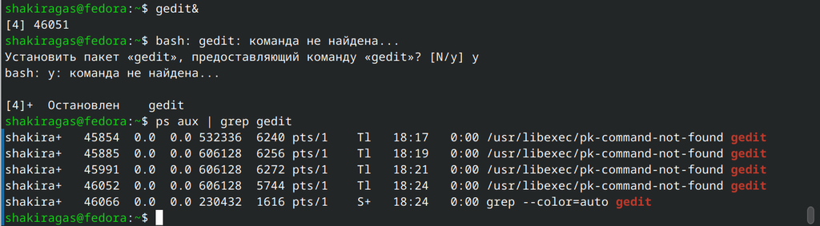

## Выполнение лабораторной работы

Читаю справку (man) команды kill

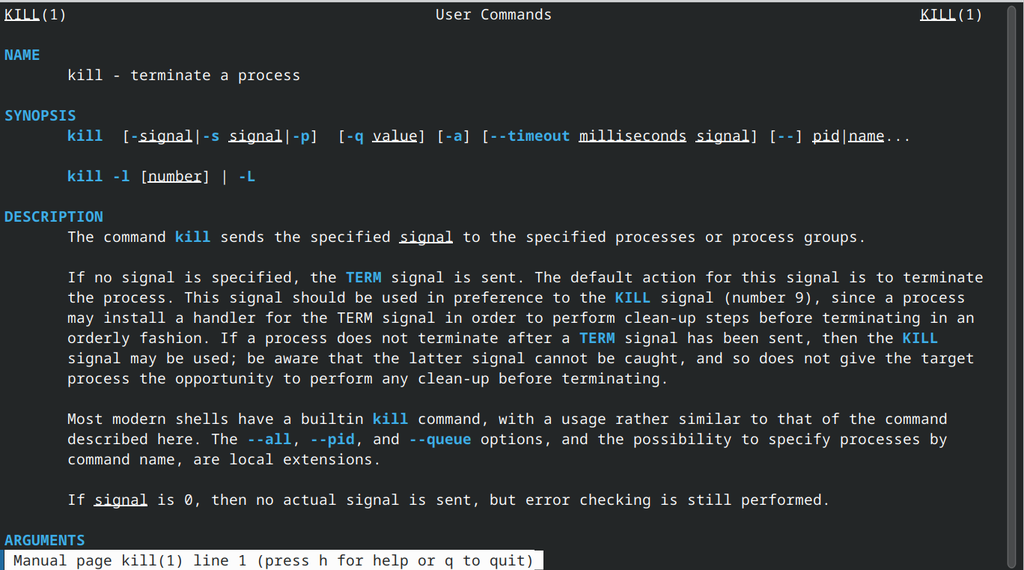

Спрввка kill

## Выполнение лабораторной работы

Использую её для завершения процесса gedit

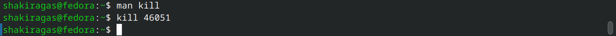

Использование kill

## Выполнение лабораторной работы

Получаю информацию об командах df и du, с помощью команды man

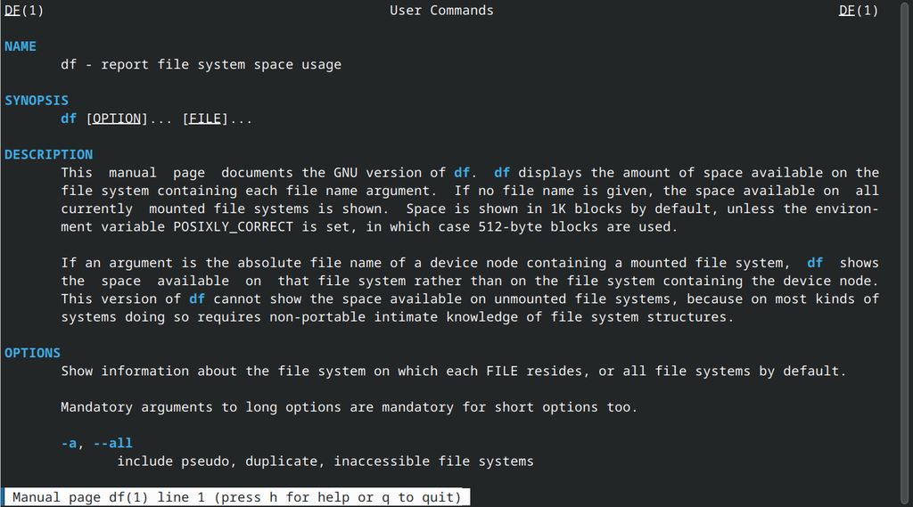

man df

## Выполнение лабораторной работы

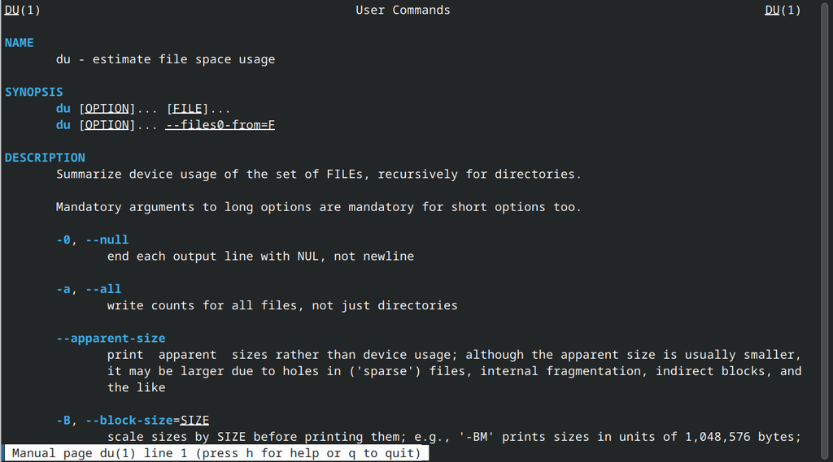

man du

## Выполнение лабораторной работы

Выполняю команды df и du

[figure not shown]

df

## Выполнение лабораторной работы

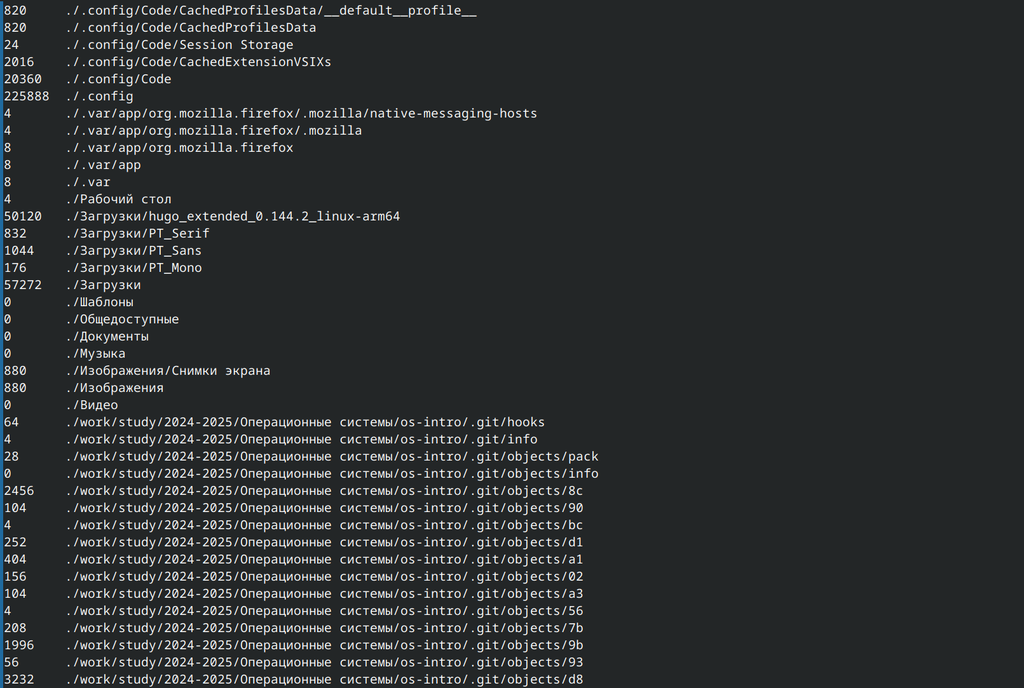

du

## Выполнение лабораторной работы

Смотрю справку команды find

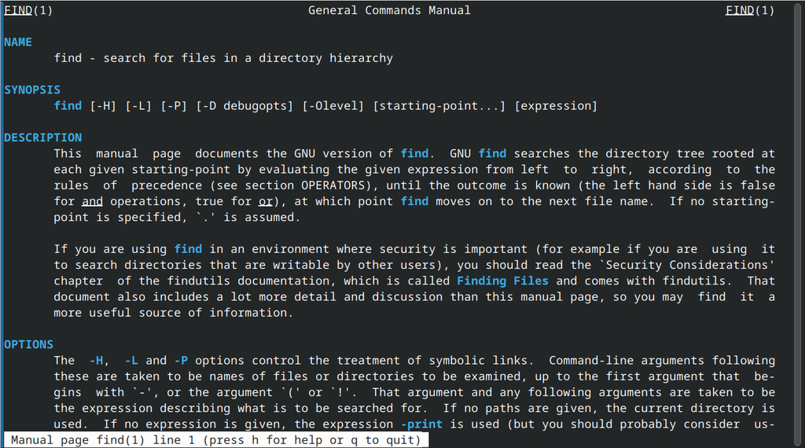

man find

## Выполнение лабораторной работы

Вывожу имена всех директорий, имеющихся в домашнем каталоге, с помощью команды find ~ -type d

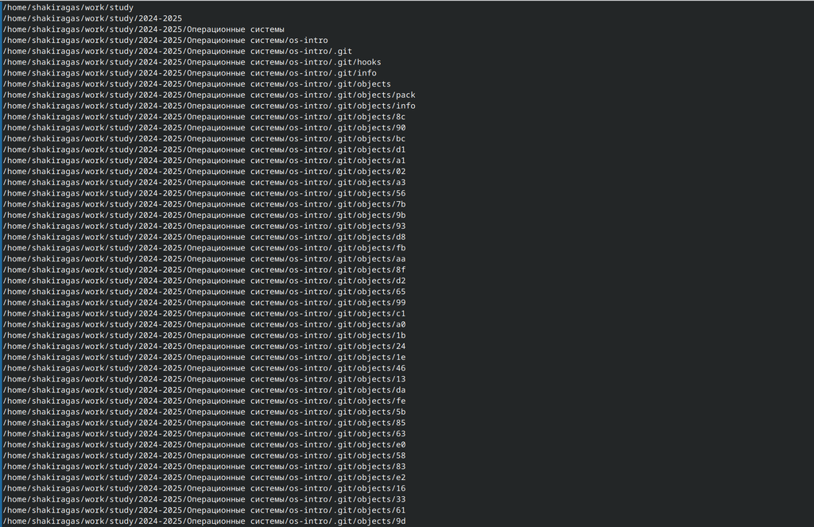

Вывод имем всех директорий домашнего каталога

## Выводы

При выполнении данной лабораторной работы я ознакомилась с инструментами поиска файлов и фильтрации текстовых данных. Приобрела практические навыки: по управлению процессами (и заданиями), по проверке использования диска и обслуживанию файловых систем.